# MNIST case study

Alessandro Aere

22nd May 2020

# Case study: image classification

## Problem description

A comparison of models will be made using the MNIST dataset, a collection of images representing handwritten digits.

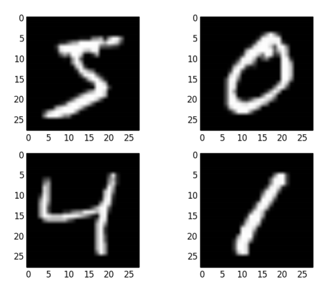

*Sample of the dataset*

More details of the datasets [here](http://yann.lecun.com/exdb/mnist/).

In this report only the code concerning neural networks will be reported, not that of all the other statistical models, as they are not a topic of interest. In the conclusion you will find, however, the comparison of the results.

## Import the Keras library

```r
devtools::install_github("rstudio/keras")
library(keras)
install_keras()
```

Run the code below if you wish to set in *seed* and obtain reproducible results.

```r
library(reticulate)
py_run_string("import numpy as np;
import tensorflow as tf;
import random as python_random;
np.random.seed(123);
python_random.seed(123);
tf.random.set_seed(123);")
```

## Data ingestion

Data will be downloaded automatically with the following commands, which are available thanks to the `keras` library.

```r
mnist <- dataset_mnist()
train_images <- mnist$train$x
train_labels <- mnist$train$y
test_images <- mnist$test$x
test_labels <- mnist$test$y
```

## Data preparation

Normalize the input data, rescaling them between 0 and 1.

```r
train_images <- train_images / 255
test_images <- test_images / 255
```

Transform the target variable into a categorical variable (using one-hot encoding).

```r
train_labels <- to_categorical(train_labels)
test_labels <- to_categorical(test_labels)
```

## Deep Neural Network

Specify the neural network’s architecture:

```r
model <- keras_model_sequential() %>%
layer_dense(units = 256, activation = "relu", input_shape = c(28 * 28)) %>%
layer_dense(units = 128, activation = "relu", input_shape = c(28 * 28)) %>%
layer_dense(units = 64, activation = "relu", input_shape = c(28 * 28)) %>%
layer_dense(units = 10, activation = "softmax")

model
```

```
## Model
## Model: "sequential"
## ________________________________________________________________________________
## Layer (type)                        Output Shape                    Param #
## ================================================================================
## dense (Dense)                       (None, 256)                     200960
## ________________________________________________________________________________
## dense_1 (Dense)                     (None, 128)                     32896
## ________________________________________________________________________________
## dense_2 (Dense)                     (None, 64)                      8256
## ________________________________________________________________________________
## dense_3 (Dense)                     (None, 10)                      650
## ================================================================================
## Total params: 242,762
## Trainable params: 242,762
## Non-trainable params: 0
## ________________________________________________________________________________
```

Compile the model:

- the optimizer used is `adam`, with the *learning rate* equals to $0.001$;
- the *cross-entropy* is used as loss function, and *accuracy* is the evaluation metric.

```r
model %>% compile(
  optimizer = optimizer_adam(lr = 0.001),
  loss = "categorical_crossentropy",
  metrics = c("accuracy")
)
```

Train the neural network.

```r
history <- model %>% fit(
  x = array_reshape(train_images, c(60000, 28 * 28)),
  y = train_labels,
  epochs = 10,
  batch_size = 32,
  validation_split = 0.2,
  verbose = 1
)
```

The plot, representing the loss function and the accuracy in relation to the number of epochs, is shown below.

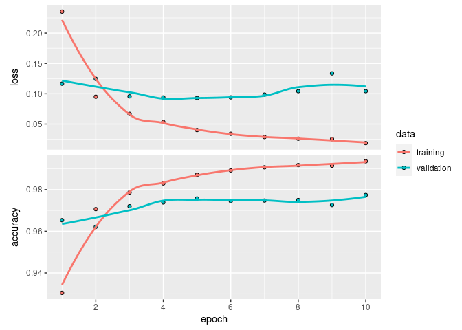

```r
plot(history)
```

Evaluating the model on the test set.

```r
results <- model %>% evaluate(
  x = array_reshape(test_images, c(10000, 28 * 28)),
  y = test_labels,
  verbose = 0
)

print(paste("Loss on test data:", results["loss"]))
```

```
## [1] "Loss on test data: 0.0877719819545746"
```

```r
print(paste("Accuracy on test data:", results["accuracy"]))
```

```
## [1] "Accuracy on test data: 0.979099988937378"
```

## Convolutional neural network

Specify the neural network’s architecture:

- the *convolutional* part of the model is a sequence of layers of type `conv`->`pool`-> `conv`->`pool`-> `conv`;
- the *fully-connected* part is a hidden layer of size $ 64 $;
- the *ReLU* function is used as the activation function in the hidden layers, and *softmax* is the activation function of the output layer.

```r
model <- keras_model_sequential() %>%
layer_conv_2d(filters = 32, kernel_size = c(3, 3), activation = "relu", input_shape = c(28, 28, 1)) %>%
layer_max_pooling_2d(pool_size = c(2, 2)) %>%
layer_conv_2d(filters = 64, kernel_size = c(3, 3), activation = "relu") %>%
layer_max_pooling_2d(pool_size = c(2, 2)) %>%
layer_conv_2d(filters = 64, kernel_size = c(3, 3), activation = "relu") %>%
layer_flatten() %>%
layer_dense(units = 64, activation = "relu") %>%
layer_dense(units = 10, activation = "softmax")

model
```

```
## Model
## Model: "sequential_1"
## ________________________________________________________________________________
## Layer (type)                        Output Shape                    Param #
## ================================================================================
## conv2d (Conv2D)                     (None, 26, 26, 32)              320
## ________________________________________________________________________________
## max_pooling2d (MaxPooling2D)        (None, 13, 13, 32)              0
## ________________________________________________________________________________
## conv2d_1 (Conv2D)                   (None, 11, 11, 64)              18496
## ________________________________________________________________________________
## max_pooling2d_1 (MaxPooling2D)      (None, 5, 5, 64)                0
## ________________________________________________________________________________
## conv2d_2 (Conv2D)                   (None, 3, 3, 64)                36928
## ________________________________________________________________________________
## flatten (Flatten)                   (None, 576)                     0
## ________________________________________________________________________________
## dense_4 (Dense)                     (None, 64)                      36928
## ________________________________________________________________________________
## dense_5 (Dense)                     (None, 10)                      650
## ================================================================================
## Total params: 93,322
## Trainable params: 93,322
## Non-trainable params: 0
## ________________________________________________________________________________
```

Compile the model:

- the optimizer used is `adam`, with the *learning rate* equals to $0.001$;
- the *cross-entropy* is used as loss function, and the *accuracy* is the evaluation metric.

```r
model %>% compile(
  optimizer = optimizer_adam(lr = 0.001),
  loss = "categorical_crossentropy",
  metrics = c("accuracy")
)
```

Train the neural network.

```r
history <- model %>% fit(
  x = array_reshape(train_images, c(60000, 28, 28, 1)),
  y = train_labels,
  epochs = 10,
  batch_size = 32,
  validation_split = 0.2,
  verbose = 1
)
```

The plot, representing the loss function and the accuracy in relation to the number of epochs, is shown below.

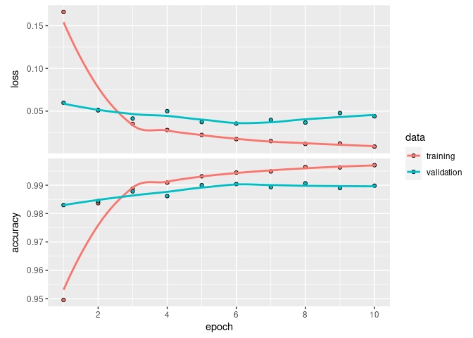

```r
plot(history)
```

Evaluating the model on the test set.

```r
results <- model %>% evaluate(
  x = array_reshape(test_images, c(10000, 28, 28, 1)),
  y = test_labels,
  verbose = 0
)

print(paste("Loss on test data:", results["loss"]))
```

```
## [1] "Loss on test data: 0.0345294252038002"
```

```r
print(paste("Accuracy on test data:", results["accuracy"]))
```

```
## [1] "Accuracy on test data: 0.991999983787537"
```

## Results

| **Model** | **Accuracy** |
| --- | --- |
| Convolutional neural network | 99.2% |
| Deep neural network | 97.9% |
| Support vector machine | 97.6% |
| Gradient boosting | 97.1% |
| K-nearest neighbours | 96.3% |
| Random forest | 96.1% |
| Classification tree | 87.6% |